# Laboratorio 10 — Aprendizaje Semi-Supervisado

CC3074 · Minería de Datos | Semestre I – 2026

2026-05-15

# 1. Selección y Análisis del Dataset

## 1.1 Descripción del dataset

El dataset utilizado es **Water Potability**, disponible públicamente en Kaggle:  
https://www.kaggle.com/datasets/adityakadiwal/water-potability

Contiene mediciones fisicoquímicas de muestras de agua y una variable objetivo binaria que indica si el agua es apta para consumo humano (`Potability`: 1 = potable, 0 = no potable). El escenario semi-supervisado es realista: en la práctica, analizar y etiquetar muestras de agua requiere laboratorios especializados, por lo que contar con pocas muestras etiquetadas y muchas sin etiquetar es completamente plausible.

```r
df <- read.csv("water_potability.csv")
```

## 1.2 Dimensionalidad y estructura

```r
cat("Filas:   ", nrow(df), "\n")
```

```
## Filas:    3276
```

```r
cat("Columnas:", ncol(df), "\n\n")
```

```
## Columnas: 10
```

```r
str(df)
```

```
## 'data.frame':    3276 obs. of  10 variables:
##  $ ph             : num  NA 3.72 8.1 8.32 9.09 ...
##  $ Hardness       : num  205 129 224 214 181 ...
##  $ Solids         : num  20791 18630 19910 22018 17979 ...
##  $ Chloramines    : num  7.3 6.64 9.28 8.06 6.55 ...
##  $ Sulfate        : num  369 NA NA 357 310 ...
##  $ Conductivity   : num  564 593 419 363 398 ...
##  $ Organic_carbon : num  10.4 15.2 16.9 18.4 11.6 ...
##  $ Trihalomethanes: num  87 56.3 66.4 100.3 32 ...
##  $ Turbidity      : num  2.96 4.5 3.06 4.63 4.08 ...
##  $ Potability     : int  0 0 0 0 0 0 0 0 0 0 ...
```

El dataset cuenta con **3276 filas** y **10 columnas**, cumpliendo con los requisitos mínimos del laboratorio (≥ 1,000 filas y ≥ 8 columnas). Las primeras 9 columnas son variables numéricas continuas que actúan como predictores, y la columna `Potability` es la variable objetivo de tipo entero binario.

```r
head(df)
```

|  | ph | Hardness | Solids | Chloramines | Sulfate | Conductivity | Organic_carbon | Trihalomethanes | Turbidity | Potability |
| --- | --- | --- | --- | --- | --- | --- | --- | --- | --- | --- |
| 1 | NA | 204.8905 | 20791.32 | 7.300212 | 368.5164 | 564.3087 | 10.379783 | 86.99097 | 2.963135 | 0 |
| 2 | 3.716080 | 129.4229 | 18630.06 | 6.635246 | NA | 592.8854 | 15.180013 | 56.32908 | 4.500656 | 0 |
| 3 | 8.099124 | 224.2363 | 19909.54 | 9.275884 | NA | 418.6062 | 16.868637 | 66.42009 | 3.055934 | 0 |
| 4 | 8.316766 | 214.3734 | 22018.42 | 8.059332 | 356.8861 | 363.2665 | 18.436524 | 100.34167 | 4.628771 | 0 |
| 5 | 9.092223 | 181.1015 | 17978.99 | 6.546600 | 310.1357 | 398.4108 | 11.558279 | 31.99799 | 4.075075 | 0 |
| 6 | 5.584087 | 188.3133 | 28748.69 | 7.544869 | 326.6784 | 280.4679 | 8.399735 | 54.91786 | 2.559708 | 0 |

## 1.3 Estadísticas descriptivas

```r
summary(df)
```

```
##        ph            Hardness          Solids         Chloramines
##  Min.   : 0.000   Min.   : 47.43   Min.   :  320.9   Min.   : 0.352
##  1st Qu.: 6.093   1st Qu.:176.85   1st Qu.:15666.7   1st Qu.: 6.127
##  Median : 7.037   Median :196.97   Median :20927.8   Median : 7.130
##  Mean   : 7.081   Mean   :196.37   Mean   :22014.1   Mean   : 7.122
##  3rd Qu.: 8.062   3rd Qu.:216.67   3rd Qu.:27332.8   3rd Qu.: 8.115
##  Max.   :14.000   Max.   :323.12   Max.   :61227.2   Max.   :13.127
##  NA's   :491
##     Sulfate       Conductivity   Organic_carbon  Trihalomethanes
##  Min.   :129.0   Min.   :181.5   Min.   : 2.20   Min.   :  0.738
##  1st Qu.:307.7   1st Qu.:365.7   1st Qu.:12.07   1st Qu.: 55.845
##  Median :333.1   Median :421.9   Median :14.22   Median : 66.622
##  Mean   :333.8   Mean   :426.2   Mean   :14.28   Mean   : 66.396
##  3rd Qu.:360.0   3rd Qu.:481.8   3rd Qu.:16.56   3rd Qu.: 77.337
##  Max.   :481.0   Max.   :753.3   Max.   :28.30   Max.   :124.000
##  NA's   :781                                     NA's   :162
##    Turbidity       Potability
##  Min.   :1.450   Min.   :0.0000
##  1st Qu.:3.440   1st Qu.:0.0000
##  Median :3.955   Median :0.0000
##  Mean   :3.967   Mean   :0.3901
##  3rd Qu.:4.500   3rd Qu.:1.0000
##  Max.   :6.739   Max.   :1.0000
##
```

```r
features <- setdiff(names(df), "Potability")

data.frame(
  Variable  = features,
  Media     = sapply(features, function(v) round(mean(df[[v]], na.rm = TRUE), 3)),
  Mediana   = sapply(features, function(v) round(median(df[[v]], na.rm = TRUE), 3)),
  SD        = sapply(features, function(v) round(sd(df[[v]], na.rm = TRUE), 3)),
  Skewness  = sapply(features, function(v) round(skewness(df[[v]], na.rm = TRUE), 4)),
  Kurtosis  = sapply(features, function(v) round(kurtosis(df[[v]], na.rm = TRUE), 4))
)
```

|  | Variable | Media | Mediana | SD | Skewness | Kurtosis |
| --- | --- | --- | --- | --- | --- | --- |
| ph | ph | 7.081 | 7.037 | 1.594 | 0.0256 | 3.7169 |
| Hardness | Hardness | 196.369 | 196.968 | 32.880 | -0.0393 | 3.6130 |
| Solids | Solids | 22014.093 | 20927.834 | 8768.571 | 0.6213 | 3.4403 |
| Chloramines | Chloramines | 7.122 | 7.130 | 1.583 | -0.0121 | 3.5872 |
| Sulfate | Sulfate | 333.776 | 333.074 | 41.417 | -0.0359 | 3.6446 |
| Conductivity | Conductivity | 426.205 | 421.885 | 80.824 | 0.2644 | 2.7215 |
| Organic_carbon | Organic_carbon | 14.285 | 14.218 | 3.308 | 0.0255 | 3.0425 |
| Trihalomethanes | Trihalomethanes | 66.396 | 66.622 | 16.175 | -0.0830 | 3.2363 |
| Turbidity | Turbidity | 3.967 | 3.955 | 0.780 | -0.0078 | 2.9355 |

La mayoría de variables presentan distribuciones aproximadamente simétricas (skewness cercano a 0). `Solids` muestra una ligera asimetría positiva. Las curtosis cercanas a 3 indican distribuciones aproximadamente normales, lo que favorece el uso de métodos basados en distancias como Label Propagation.

## 1.4 Valores faltantes

```r
na_counts <- colSums(is.na(df))
na_pct    <- round(na_counts / nrow(df) * 100, 2)

data.frame(
  Variable   = names(na_counts),
  NAs        = as.integer(na_counts),
  Porcentaje = paste0(na_pct, "%")
) %>% filter(NAs > 0)
```

| Variable | NAs | Porcentaje |
| --- | --- | --- |
| ph | 491 | 14.99% |
| Sulfate | 781 | 23.84% |
| Trihalomethanes | 162 | 4.95% |

Tres variables presentan datos faltantes: `ph` (15%), `Sulfate` (24%) y `Trihalomethanes` (5%). Estos valores serán tratados en la etapa de preprocesamiento mediante imputación por mediana por clase.

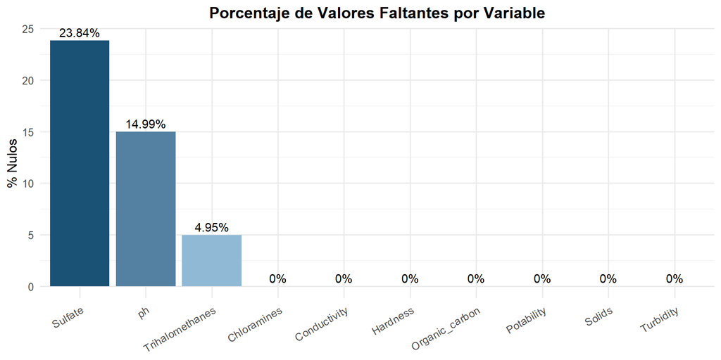

```r
data.frame(Variable = names(na_pct), Porcentaje = as.numeric(na_pct)) %>%
  ggplot(aes(x = reorder(Variable, -Porcentaje), y = Porcentaje, fill = Porcentaje)) +
  geom_bar(stat = "identity") +
  geom_text(aes(label = paste0(Porcentaje, "%")), vjust = -0.4, size = 3.8) +
  scale_fill_gradient(low = "#AED6F1", high = "#1A5276") +
  labs(title = "Porcentaje de Valores Faltantes por Variable",
       x = NULL, y = "% Nulos") +
  theme_minimal(base_size = 12) +
  theme(legend.position = "none",
        axis.text.x = element_text(angle = 30, hjust = 1),
        plot.title = element_text(hjust = 0.5, face = "bold"))
```

## 1.5 Balance de clases

```r
balance <- table(df$Potability)
data.frame(
  Clase      = c("0 — No Potable", "1 — Potable"),
  Frecuencia = as.integer(balance),
  Porcentaje = paste0(round(as.numeric(balance) / sum(balance) * 100, 1), "%")
)
```

| Clase | Frecuencia | Porcentaje |
| --- | --- | --- |
| 0 — No Potable | 1998 | 61% |
| 1 — Potable | 1278 | 39% |

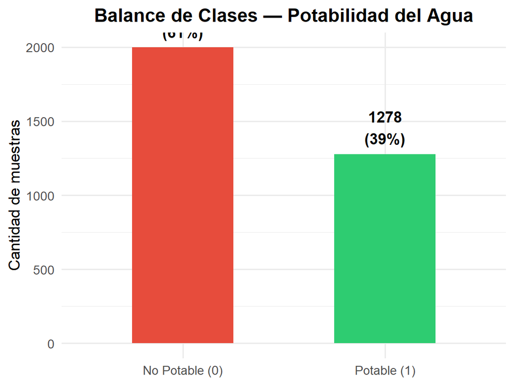

```r
data.frame(
  Clase = c("No Potable (0)", "Potable (1)"),
  n     = as.integer(balance),
  pct   = round(as.numeric(balance) / sum(balance) * 100, 1)
) %>%
  ggplot(aes(x = Clase, y = n, fill = Clase)) +
  geom_bar(stat = "identity", width = 0.5) +
  geom_text(aes(label = paste0(n, "\n(", pct, "%)")),
            vjust = -0.3, size = 4.5, fontface = "bold") +
  scale_fill_manual(values = c("#E74C3C", "#2ECC71")) +
  labs(title = "Balance de Clases — Potabilidad del Agua",
       x = NULL, y = "Cantidad de muestras") +
  theme_minimal(base_size = 13) +
  theme(legend.position = "none",
        plot.title = element_text(hjust = 0.5, face = "bold"))
```

El dataset presenta un **leve desbalance**: 61% de muestras no potables vs. 39% potables. Este desbalance no es severo, pero será considerado al momento de evaluar métricas (se priorizará F1-score sobre accuracy).

## 1.6 Distribución de variables

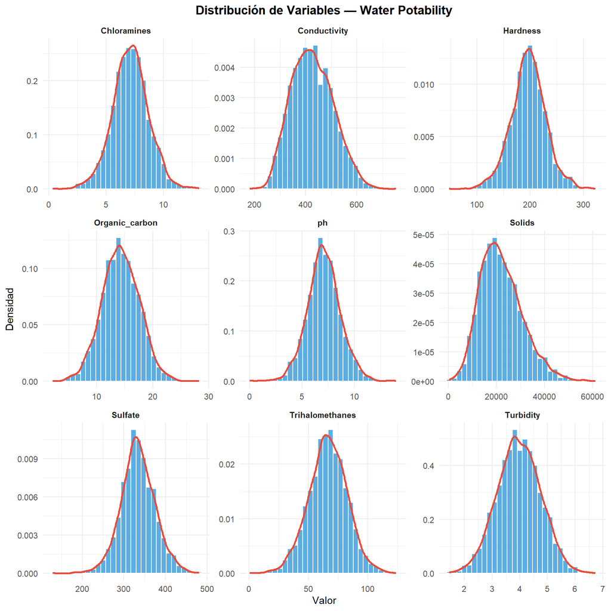

```r
df %>%
  select(all_of(features)) %>%
  pivot_longer(everything(), names_to = "Variable", values_to = "Valor") %>%
  ggplot(aes(x = Valor)) +
  geom_histogram(aes(y = after_stat(density)), bins = 30,
                 fill = "#3498DB", color = "white", alpha = 0.8) +
  geom_density(color = "#E74C3C", linewidth = 1) +
  facet_wrap(~Variable, scales = "free", ncol = 3) +
  labs(title = "Distribución de Variables — Water Potability",
       x = "Valor", y = "Densidad") +
  theme_minimal(base_size = 11) +
  theme(plot.title = element_text(hjust = 0.5, face = "bold"),
        strip.text = element_text(face = "bold"))
```

Las variables presentan distribuciones aproximadamente normales o con ligera asimetría. `Solids` muestra una cola derecha más pronunciada. No se observan distribuciones bimodales marcadas, lo que sugiere que las clases comparten rangos de valores similares — escenario ideal para explorar con aprendizaje semi-supervisado basado en grafos (Label Propagation).

## 1.7 Boxplots por clase

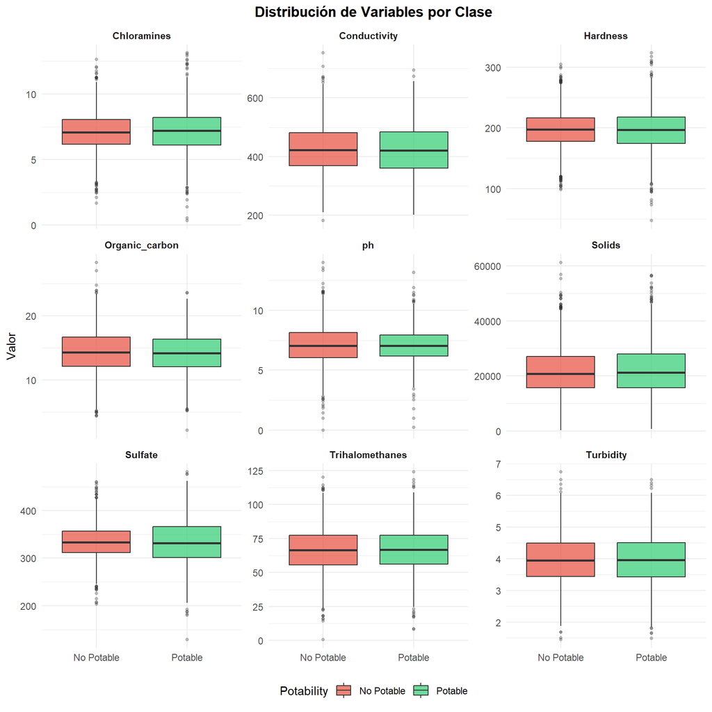

```r
df %>%
  pivot_longer(all_of(features), names_to = "Variable", values_to = "Valor") %>%
  mutate(Potability = factor(Potability, levels = c(0, 1),
                             labels = c("No Potable", "Potable"))) %>%
  ggplot(aes(x = Potability, y = Valor, fill = Potability)) +
  geom_boxplot(alpha = 0.7, outlier.alpha = 0.3, outlier.size = 1) +
  scale_fill_manual(values = c("#E74C3C", "#2ECC71")) +
  facet_wrap(~Variable, scales = "free_y", ncol = 3) +
  labs(title = "Distribución de Variables por Clase",
       x = NULL, y = "Valor") +
  theme_minimal(base_size = 11) +
  theme(legend.position = "bottom",
        plot.title = element_text(hjust = 0.5, face = "bold"),
        strip.text = element_text(face = "bold"))
```

Los boxplots revelan que ninguna variable por sí sola separa perfectamente las clases, lo que justifica el uso de modelos que aprovechen la estructura global de los datos (como Label Propagation) en lugar de depender únicamente de los pocos datos etiquetados.

## 1.8 Matriz de correlación

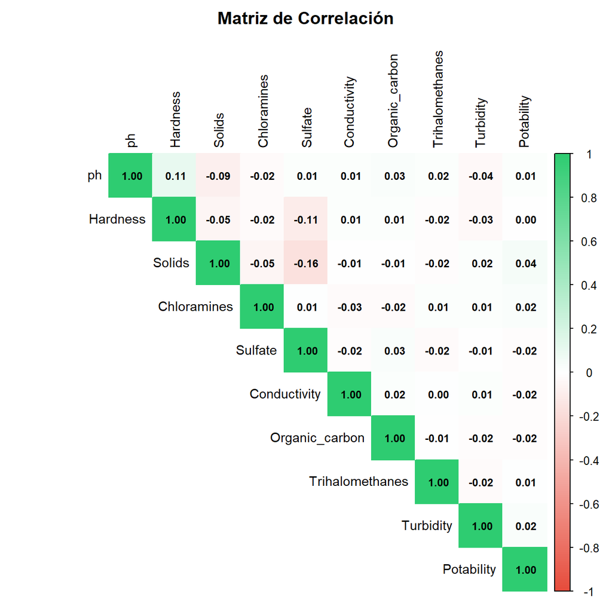

```r
df_completo <- df %>% drop_na()
cor_matrix  <- cor(df_completo)

corrplot(cor_matrix,
         method      = "color",
         type        = "upper",
         tl.col      = "black",
         tl.cex      = 0.9,
         addCoef.col = "black",
         number.cex  = 0.75,
         col = colorRampPalette(c("#E74C3C", "white", "#2ECC71"))(200),
         title = "Matriz de Correlación",
         mar   = c(0, 0, 2, 0))
```

Las correlaciones entre predictores son bajas en general, lo que indica que las variables aportan información independiente. Esto es favorable para el escenario semi-supervisado: los algoritmos basados en grafos (Label Propagation) se benefician de features con baja multicolinealidad para construir una estructura de similitud más representativa.

# 2. Preprocesamiento de Datos

## 2.1 Imputación de valores faltantes

Se imputan los valores faltantes usando la **mediana por clase** (potable vs. no potable). Esta estrategia es preferida sobre la media global porque:

1. La mediana es robusta ante outliers.
2. Imputar por clase evita mezclar la distribución de ambas clases, lo que introduciría sesgo hacia el target.
3. En un escenario semi-supervisado, preservar la separación entre clases es crucial desde el preprocesamiento.

```r
imputar_mediana_clase <- function(data, variable) {
  medianas <- data %>%
    group_by(Potability) %>%
    summarise(mediana = median(.data[[variable]], na.rm = TRUE), .groups = "drop")

  for (i in 1:nrow(medianas)) {
    clase   <- medianas$Potability[i]
    mediana <- medianas$mediana[i]
    data[[variable]][is.na(data[[variable]]) & data$Potability == clase] <- mediana
  }
  return(data)
}

df_clean <- df
vars_con_na <- c("ph", "Sulfate", "Trihalomethanes")

for (v in vars_con_na) {
  df_clean <- imputar_mediana_clase(df_clean, v)
}

# Verificación
data.frame(
  Variable = names(df_clean),
  NAs_restantes = colSums(is.na(df_clean))
)
```

|  | Variable | NAs_restantes |
| --- | --- | --- |
| ph | ph | 0 |
| Hardness | Hardness | 0 |
| Solids | Solids | 0 |
| Chloramines | Chloramines | 0 |
| Sulfate | Sulfate | 0 |
| Conductivity | Conductivity | 0 |
| Organic_carbon | Organic_carbon | 0 |
| Trihalomethanes | Trihalomethanes | 0 |
| Turbidity | Turbidity | 0 |
| Potability | Potability | 0 |

## 2.2 Tratamiento de outliers (Winsorización)

En lugar de eliminar filas con outliers (lo que reduciría el dataset), se aplica **winsorización al 1.5×IQR**: los valores por debajo del límite inferior o por encima del límite superior del rango intercuartílico se recortan al límite más cercano. Esto preserva todas las observaciones y reduce el impacto de valores extremos en los algoritmos sensibles a distancias.

```r
winsorizacion <- function(x) {
  Q1  <- quantile(x, 0.25)
  Q3  <- quantile(x, 0.75)
  IQR <- Q3 - Q1
  pmax(pmin(x, Q3 + 1.5 * IQR), Q1 - 1.5 * IQR)
}

df_proc <- df_clean

outliers_df <- data.frame(
  Variable        = features,
  Outliers_antes  = sapply(features, function(v) {
    Q1 <- quantile(df_proc[[v]], 0.25)
    Q3 <- quantile(df_proc[[v]], 0.75)
    IQR <- Q3 - Q1
    sum(df_proc[[v]] < Q1 - 1.5 * IQR | df_proc[[v]] > Q3 + 1.5 * IQR)
  })
)

for (v in features) df_proc[[v]] <- winsorizacion(df_proc[[v]])

print(outliers_df)
```

```
##                        Variable Outliers_antes
## ph                           ph            142
## Hardness               Hardness             83
## Solids                   Solids             47
## Chloramines         Chloramines             61
## Sulfate                 Sulfate            264
## Conductivity       Conductivity             11
## Organic_carbon   Organic_carbon             25
## Trihalomethanes Trihalomethanes             54
## Turbidity             Turbidity             19
```

## 2.3 Normalización Min-Max

Se aplica **escalado Min-Max** para llevar todas las variables al rango **[0, 1]**. Esto es necesario porque:

- **Label Propagation** construye un grafo de similitud basado en distancias; variables con escalas muy diferentes dominarían el cálculo.
- **Self-Training con SVM** es especialmente sensible a la escala de los datos.
- La normalización preserva la forma de la distribución original.

```r
min_max_scale <- function(x) (x - min(x)) / (max(x) - min(x))

df_norm           <- df_proc
df_norm[features] <- lapply(df_proc[features], min_max_scale)
df_norm$Potability <- factor(df_proc$Potability,
                             levels = c(0, 1),
                             labels = c("No Potable", "Potable"))

# Verificar rangos
data.frame(
  Variable = features,
  Min      = sapply(features, function(v) round(min(df_norm[[v]]), 4)),
  Max      = sapply(features, function(v) round(max(df_norm[[v]]), 4))
)
```

|  | Variable | Min | Max |
| --- | --- | --- | --- |
| ph | ph | 0 | 1 |
| Hardness | Hardness | 0 | 1 |
| Solids | Solids | 0 | 1 |
| Chloramines | Chloramines | 0 | 1 |
| Sulfate | Sulfate | 0 | 1 |
| Conductivity | Conductivity | 0 | 1 |
| Organic_carbon | Organic_carbon | 0 | 1 |
| Trihalomethanes | Trihalomethanes | 0 | 1 |
| Turbidity | Turbidity | 0 | 1 |

## 2.4 Distribuciones antes vs. después del preprocesamiento

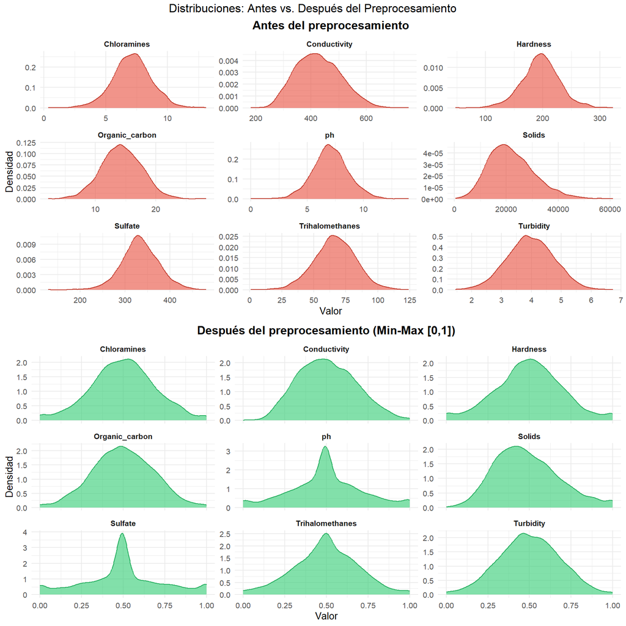

```r
# Gráfico "Antes": con datos originales (escala real)
p_antes <- df %>%
  select(all_of(features)) %>%
  pivot_longer(everything(), names_to = "Variable", values_to = "Valor") %>%
  ggplot(aes(x = Valor)) +
  geom_density(fill = "#E74C3C", alpha = 0.6, color = "#C0392B") +
  facet_wrap(~Variable, scales = "free", ncol = 3) +
  labs(title = "Antes del preprocesamiento", x = "Valor", y = "Densidad") +
  theme_minimal(base_size = 10) +
  theme(plot.title = element_text(hjust = 0.5, face = "bold"),
        strip.text = element_text(face = "bold"))

# Gráfico "Después": datos normalizados [0,1]
p_despues <- df_norm %>%
  select(all_of(features)) %>%
  pivot_longer(everything(), names_to = "Variable", values_to = "Valor") %>%
  ggplot(aes(x = Valor)) +
  geom_density(fill = "#2ECC71", alpha = 0.6, color = "#27AE60") +
  facet_wrap(~Variable, scales = "free_y", ncol = 3) +
  labs(title = "Después del preprocesamiento (Min-Max [0,1])", x = "Valor", y = "Densidad") +
  theme_minimal(base_size = 10) +
  theme(plot.title = element_text(hjust = 0.5, face = "bold"),
        strip.text = element_text(face = "bold"))

grid.arrange(p_antes, p_despues, nrow = 2,
             top = "Distribuciones: Antes vs. Después del Preprocesamiento")
```

## 2.5 Resumen del preprocesamiento

```r
cat("Dataset original:      ", nrow(df), "filas ×", ncol(df), "columnas\n")
```

```
## Dataset original:       3276 filas × 10 columnas
```

```r
cat("Dataset preprocesado:  ", nrow(df_norm), "filas ×", ncol(df_norm), "columnas\n")
```

```
## Dataset preprocesado:   3276 filas × 10 columnas
```

```r
cat("NAs restantes:         ", sum(is.na(df_norm[features])), "\n")
```

```
## NAs restantes:          0
```

```r
cat("Rango de variables:    [0, 1] para todas las features\n")
```

```
## Rango de variables:    [0, 1] para todas las features
```

```r
write.csv(df_norm, "water_potability_preprocesado.csv", row.names = FALSE)
```

El dataset preprocesado queda listo para la etapa de diseño experimental, donde se simulará el escenario semi-supervisado asignando etiquetas únicamente a una fracción del conjunto de entrenamiento (5%, 10% y 20%).